# Verzani Problem Set

Next are considered the problems from Verzani’s book on page $92$.

## Problem 15.1

The dataset `InsectSpray` has data on the count of insects in areas treated with one of $6$ different types of sprays. The dataset is already in the proper format for the one-way analysis of variance - a vector with the data `count`, and one with a factor describing the level `spray`. First make a side-by-side boxplot to see if the means are equal. Then perform a one-way ANOVA to check if they are. Do they agree?

$Y$ is the count of insects.

$X$ is the type of the spray. It has $6$ levels: $A$, $B$, $C$, $D$, $E$ and $F$.

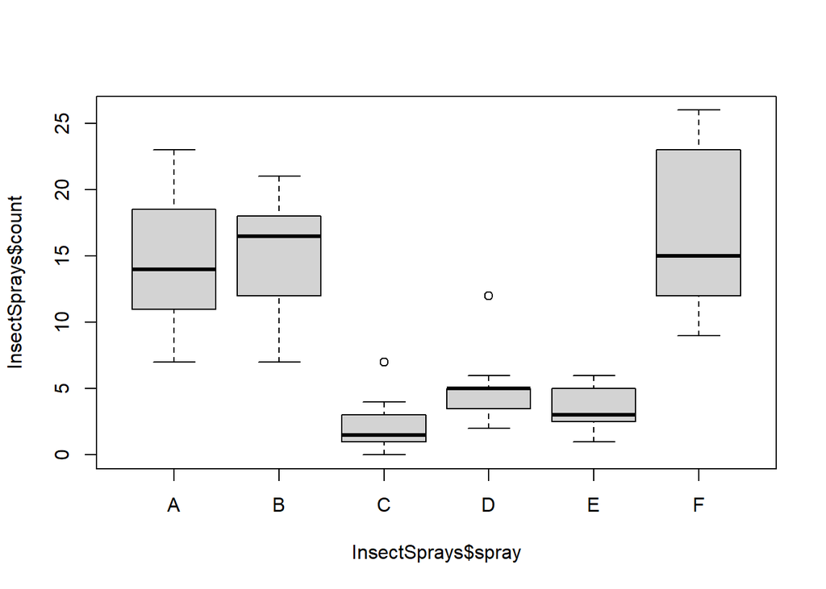

```r
> head(InsectSprays)
  count spray
1    10     A
2     7     A
3    20     A
4    14     A
5    14     A
6    12     A
> boxplot(InsectSprays$count ~ InsectSprays$spray)
```

Are the differences between these means statistically significant?

$H_0: \mathbb{E}(Y | X = A) = \mathbb{E}(Y | X = B) = \mathbb{E}(Y | X = C) = \mathbb{E}(Y | X = D) = \mathbb{E}(Y | X = E) = \mathbb{E}(Y | X = F)$

$H_A:$ At least two of $\mathbb{E}(Y | X = A),\ \mathbb{E}(Y | X = B),\ \mathbb{E}(Y | X = C),\ \mathbb{E}(Y | X = D),\ \mathbb{E}(Y | X = E)$ and $\mathbb{E}(Y | X = F)$ are different.

or which is the same as

$H_0: \sigma_B^2 = \sigma_W^2$

$H_A: \sigma_B^2 \neq \sigma_W^2$

```r
> myanova <- aov(count ~ spray, data = InsectSprays)
> summary(myanova)
            Df Sum Sq Mean Sq F value Pr(>F)
spray        5   2669   533.8    34.7 <2e-16 ***
Residuals   66   1015    15.4
---
Signif. codes:  0 '***' 0.001 '**' 0.01 '*' 0.05 '.' 0.1 ' ' 1
```

The first three numbers in the row `spray` are for the degrees of freedom, $SS_B$ and $MS_B$.

The first three numbers in the row `Residuals` are for the degrees of freedom, $SS_W$ and $MS_W$.

The number `F value` is for $F_{emp} = \frac{MS_B}{MS_W} = 34.702$

The corresponding $p-value = \mathbb{P}(F_{stat} > F_{emp}|H_0) = \mathbb{P}(\eta > F_{emp}) < 2.2e-16 < 0.05 = \alpha$, so we reject $H_0$. According to the data the spray is statistically significant for the number of the insects in the area.

## Problem 15.2

The `newcar` data set from [here](https://www.itl.nist.gov/div898/education/anova/newcar.dat) contains the interest rates in $6$ different towns. Customer would like to know if there is statistically significant difference between the interest rates in these towns. Do a one-way analysis of variance to test the hypothesis that the interest rates are the same for all $6$ towns. What do you conclude?

```r
> library(readr)
> newcar <- read_table2("Data/newcar.dat", col_names = c("Rate", "City"), skip = 24, comment = "--")

-- Column specification --------------------------------------------------------
cols(
  Rate = col_double(),
  City = col_double()
)
```

```r
> head(newcar)
# A tibble: 6 x 2
   Rate  City
  <dbl> <dbl>
1  13.8     1
2  13.8     1
3  13.5     1
4  13.5     1
5  13       1
6  13       1
```

```r
> myanova <- aov(Rate ~ City, data = newcar)
> summary(myanova)
            Df Sum Sq Mean Sq F value Pr(>F)
City         1   0.75  0.7516   1.223  0.274
Residuals   52  31.95  0.6145
```

The first three numbers in the row `Residuals` are for the degrees of freedom, $SS_W$ and $MS_W$.

The number `F value` is for $F_{emp} = \frac{MS_B}{MS_W} = 1.223$